# Computational Statistics 13.1 Supervised Learning

## Supervised learning

### Overview

This lesson introduces supervised learning and out-of-sample validation.

### Objectives

After completing this module, students should be able to:

1. Employ out-of-sample testing to validate models.

### Readings

Lander, 18.3

## “Big data” again

In the previous module we used unsupervised machine learning (UML) to detect patterns in a dataset with a large number of variables, either using factors or clusters. We call this method “unsupervised” because we are not interested in predicting the variation in a single variable in the dataset.

This week we start with supervised machine learning (SML), the main difference between the two methods is that with SML we are interested in **predicting** a specific variable in our dataset using the rest of the available information.

You may ask, why not use multivariate regression? the reason is that with *big data* there are so many variables that the procedures used in the previous modules are impractical. Additionally, SML is not a method designed for testing hypothesis, but for prediction. This means that we are not longer interested in estimating the causal effect of a specific $x$ over $y$, but how a set of $x$ can predict $y$. The good news is that if we are only interested in prediction we don’t have to worry about OVB and multicollinearity, the bad news is that even if we have a very good prediction of $y$ we cannot use SML to establish causality nor test hypothesis.

We can use SML to predict $y$ and, as in the case of multivariate regression, the method is slightly different depending on the nature of the dependent variable:

## Overfitting

With **big data** we are working on the assumption that we have a very large number of variables. Using the same notation from multivariate analysis, let’s call the number of independent variables $k$ and the number of observations $n$.

- When the number of independent variables $k$ is relatively large to the number of observations $n$. A linear model will suffer from a problem known as **overfitting**.
- Imagine for instance that we have $k = 2$ variables and $n = 2$ observations. If we are using the $k$ variables to predict $y$ in a linear model, we have a system that looks like this:

$$\begin{eqnarray*}
y_{1} & = & a_{1}x_{1,1} + a_{2}x_{1,2} \\
y_{2} & = & a_{1}x_{2,1} + a_{2}x_{2,2}
\end{eqnarray*}$$

where $y_{i}$ is the value of $y$ for observation $i$, and $x_{i,j}$ is the value of variable $x_{j}$ for observation $i$. Is easy to show, with a little bit of algebra, that we can always find the exact values of the parameters in the previous system $a = \{a_{1}, a_{2}\}$. For instance, in this case the solution is:

$$\begin{eqnarray*}
a_{1} & = & \dfrac{y_{1}x_{2,2}-y_{2}x_{1,2}}{x_{1,1}x_{2,2} - x_{1,2}x_{2,1}} \\
a_{2} & = & \dfrac{y_{2}x_{1,1}-y_{1}x_{2,1}}{x_{1,1}x_{2,2} - x_{1,2}x_{2,1}}
\end{eqnarray*}$$

As you can see, this values are an exact function of the sample, and thus, will change from one sample to the next. This is problematic, because if we want to predict $y$ using the estimated parameters, they are only useful for the current sample. As soon as the values of the $x$ variables change, the parameters will change and the predictions will be in essence random.

- This is the problem of **overfitting**, we are predicting the current sample so well because we have sufficient data to make **perfect** predictions, that the estimated parameters are only good with the current sample. And as soon as we use a different sample, the predictive ability of the model disappears.
- The problem of **overfitting** is worse the greater the gap between $k$ and $n$.

### Overfitting Example (1/3)

- We are going to illustrate the problem of over-fitting with a simulation.
- The goal is to demonstrate that we can almost perfectly predict any $y$ values with a large set of $x$.

```r
n <- 24 # Number of observations
k <- 10 # Number of explanatory variables

# Simulating dependent variable
y <- rnorm(n)

# Simulating independent variables
x <- rnorm(n*k) # simulating n*k random obseravtions
dim(x) <- c(n,k) # setting dimension of dataset

# Making dataset
dataf = data.frame(y, x)

# Taking small sample of data, using the rest for testing
insample <- dataf[1:12,]
```

**Note**: $y$ is **not** a function of any of the $x$ variables! Therefore, the values of $x$ should offer *no* power to predict $y$, since they have nothing to do with each other.

### Overfitting Example (2/3)

But what happens if we regress $y$ on the set of $x$?

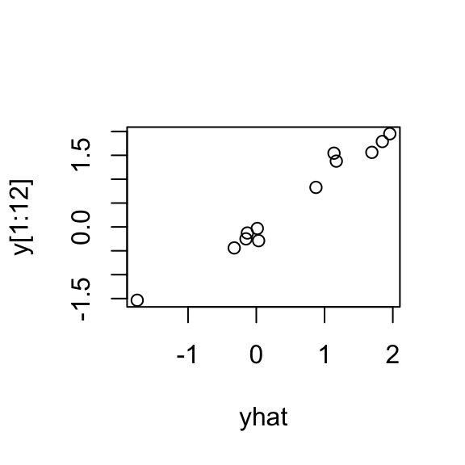

```r
lmout <- lm(y~X1+X2+X3+X4+X5+X6+X7+X8+X9+X10,data=insample)
yhat <- predict(lmout)
plot(yhat,y[1:12])
```

- We do a really good job matching our predicted $\hat{y}$ to the real $y$ values, even though there is no connection between $y$ and $x$. Some amateur statisticians would pat themselves in the back after seeing such a perfect model.
- **Problem of over-fitting:** we match the $y$ so well with the $x$ variables just due to the fact that we have a lot of them.

Over-fitting Example (3/4)

Note that a regression model is not *fooled* by overfitting:

```r
suppressMessages(library(stargazer))
stargazer(lmout, header = FALSE, type = "html")
```

|  | *Dependent variable:* |
| --- | --- |
|  | y |
| X1 | 0.198 |
|  | (0.399) |
| X2 | 0.191 |
|  | (2.573) |
| X3 | -0.610 |
|  | (0.516) |
| X4 | 1.150 |
|  | (3.277) |
| X5 | -0.179 |
|  | (0.374) |
| X6 | -0.699 |
|  | (0.392) |
| X7 | 0.660 |
|  | (0.439) |
| X8 | 1.152 |
|  | (3.871) |
| X9 | -0.186 |
|  | (0.678) |
| X10 | 0.957 |
|  | (0.664) |
| Constant | -0.030 |
|  | (1.053) |
| Observations | 12 |
| R<sup>2</sup> | 0.971 |
| Adjusted R<sup>2</sup> | 0.677 |
| Residual Std. Error | 0.635 (df = 1) |
| F Statistic | 3.305 (df = 10; 1) |
| *Note:* | p<0.1; p<0.05; p<0.01 |

**Interpretation:**

- The $R^2$ is very high! this makes sense given the previous picture.
- Take a look at the The f test’s p-value at the bottom of the table. What’s the conclusion of the test?
- Also, inspect the individual p-values for all the coefficients at $\alpha = 0.95$.
- In short: we seem to be explaining the variable $y$ due to over-fitting and chance. This is one way of identifying overfitting, high $R^2$ and not-significant parameters.

### Overfitting Example (3/3)

You may wonder, how well does the model predicts the data that we didn’t use. Let’s take a look:

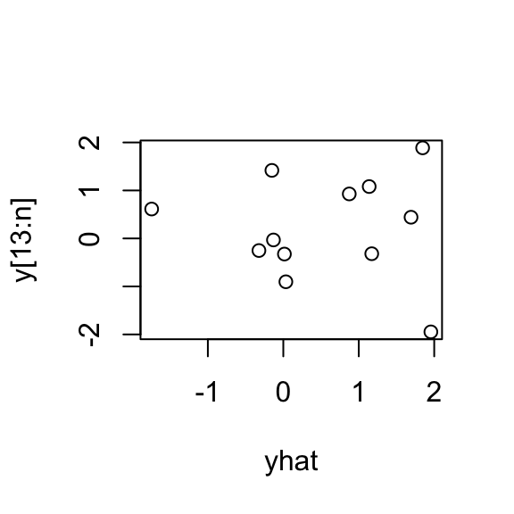

```r
yhat <- predict(lmout, data = dataf[13:n, 2:k])
plot(yhat,y[13:n])
```

That’s terrible. We are not even close to predicting the actual values when using the rest of the data. In summary, when $k$ is very large we can almost *perfectly predict* any sample due to over-fitting. But that’s not an indication that we have a model that will perform well when using data from the population in general.

## Out-sample-testing

The fundamental idea behind modeling data is to detect **underlying relationships that are true and independent of a randomly selected sample from the population**.

- Then, we’ll prefer a model that, using a set of $x$ to predict $y$ in random sample 1, it also do so relatively well in sample 2 – and in other any other random sample taken from the population –.
- This process of verifying how well the model performs in different samples is known as **out-of-sample validation**, and is how the techniques we’ll describe in the next lessons are able to overcome the problem of over-fitting.

### General instructions

In general, we can perform an out-of-sample validation for a given model by following this steps:

1. Draw a random sample from the population.
2. Estimate a model of $y$ as a function of the $x$ variables using the sample from (1), this will produce some estimated parameters $\mathbf{\beta}$. Note that, as previously illustrated, this parameters may be useless in other samples and may be over-fitting the first sample.
3. Draw a second sample from the population, and from that sample, use the new $x$ values and the estimated coefficients from step (2) to predict $\hat{y}$ for the new observations.
4. Compare the predicted $\hat{y}$ to the true values $y$ values for the second sample. If those predictions are better than we might have done by chance (eg, just guessing the mean $\bar{y}$ for every $y_i$), then the model estimated in (2) is a good model for both samples, and not just a chance artifact of the first sample.
- Step 4 can be expanded to compare multiple different models.
- The model that yields the better prediction of $y$ in sample 2 using the coefficients derived from sample 1, the better that model is performing in out-of-sample data.
- Thus, we can rank different models for generating $\hat{y}$ based on how well they have done out-of-sample.

### Regression Statistics

**Why do we need out-of-sample testing when the whole point of the statistical tests for the signficance of the $\beta$ coefficients was to determine whether they were signficant or not?**

**True:**

- For multiple regression, the statistics are well-developed, and we do have the statistical test to answer this.
- In fact, if we estimate $\beta$ using a sample (as we usually do), and get a 95% CI for $\beta$, then if we take another 100 complete samples each of size $n$ and estimate $\beta$ for each one, we should find that approximately 95 those $\beta$ values fall within the 95% CI for our first $\beta$.
- The statistical standard error predicts exactly what we would get if we did run multiple out-of-sample tests.
- That’s why in the previous example, the regression was not *fooled*, and none of the parameters was significative at $\alpha = 0.95$.

**But:**

- Many other methods are more complex than multiple regression, and we cannot derive the complete statistics for errors and p values on their coefficients. Especially, when the the relations are non-linear.
- We need some more theory-independent method for testing the validity of those models, and evaluating their relative accuracy.

### Out-of-sample testing

- Without knowing anything of the estimated statistics of a model (standard errors of, parameters, etc.), we can still test its validity to the population as a whole by out-of-sample testing.
- We would fit the model on sample 1, and then use the fitted coefficients (or other parameters) from sample 1 to predict $\hat{y}$ in sample 2 using the new $x$ values in sample 2.
- This is a black-box procedure: we don’t have to know anything about the method that was used to fit the model in sample 1 or to predict $\hat{y}$ in sample 2. We only care about how well is the model performing out-of-sample.

## Regression Example

Let’s examine the concept of out-of-sample testing with some simulated data,

### Example (1/3)

Consider the following simulation, which consists of 20 observations, a random x variable, and a y variable that we construct to be $y = 3x + \epsilon$, where as usual $\epsilon$ is just random noise:

```r
set.seed(2)
x <- rnorm(20)
y <- 3*x + rnorm(20)
dataf <- data.frame(y=y,x=x)
```

We divide that data into two halves, the first 10 observations and the second.

```r
insample <- dataf[1:10,]
outsample <- dataf[11:20,]
```

Note that since there’s no order to the observations, it doesn’t matter whether we take the first 10 and second 10, or every other observation, or some random subset; nor does it matter for our purposes here whether the two samples are the same size or different sizes.

### Example (2/3)

Next we regress $y$ on $x$ using just the in-sample observations, and show the regression results – which correctly capture the model we constructed at the beginning ($y = 3x + \epsilon$)

```r
lmout <- lm(y~x,data=insample)
stargazer(lmout, header = FALSE, type = "html")
```

|  | *Dependent variable:* |
| --- | --- |
|  | y |
| x | 2.918*** |
|  | (0.515) |
| Constant | 0.312 |
|  | (0.493) |
| Observations | 10 |
| R<sup>2</sup> | 0.800 |
| Adjusted R<sup>2</sup> | 0.775 |
| Residual Std. Error | 1.522 (df = 8) |
| F Statistic | 32.085*** (df = 1; 8) |
| *Note:* | p<0.1; p<0.05; p<0.01 |

Finally we predict $\hat{y} = \hat{\beta}x$ using the built-in `predict` function, and then we plot those predicted values against the true $y$ values:

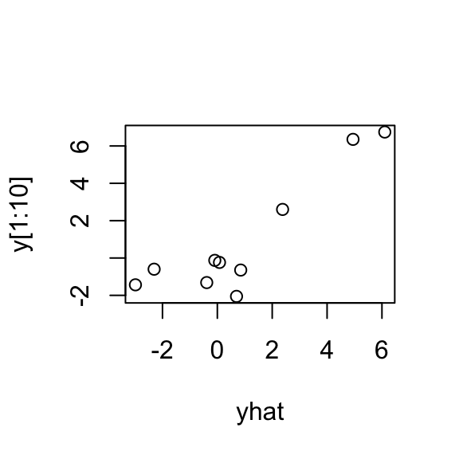

```r
yhat <- predict(lmout)
plot(yhat,y[1:10])
```

Pretty accurate! The model, at least when fit on the in-sample and then tested on the in-sample, does pretty well.

### Example (3/3)

How well do we do using the second, out-sample? Well, we can use `predict` again, which takes the $\hat{\beta}$ that we estimated in `lmout` and uses the new data we specify with `newdata=`, where here we use the second 10 observations:

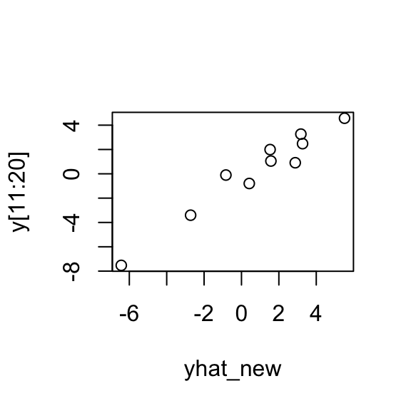

```r
yhat_new <- predict(lmout,newdata=outsample)
plot(yhat_new,y[11:20])
```

Here too we do fairly well: the out-sample $\hat{y}$ values predicted from the out-sample $x$ values and the in-sample $\hat{\beta}$ coefficient nevertheless match fairly closely the true out-sample $y$ values.

That is, our original regression captured something truly in the population (that is, the model we specified for all the data, $y = 3x + \epsilon$), not just a random characteristic of our in-sample data

- In this example we don’t have over-fitting because the number of variables $k$ is relatively low compared to the sample size $n$.

### Conclusion

- Out-of-sample accuracy can serve as the benchmark to draw conclusions about a broader population.
- Given some in-sample data, we can fit a model, and then we are given some new out-sample data to predict on.

## Cross-Validation

- Validating a model using out-of-sample testing within a dataset is known as **cross-validation**.
- Previously we simply use a graph of $\hat{y}$ on $y$ to know if the fit was *good* or not. But this is subjective, instead we prefer to use a quantitative measure like:
  - **Mean Absolute Error (MAE)**:
    $$1/n \sum_{i=1}^n |y_i-\hat{y_i}|$$
  - **Mean Squared Errror (MSE)**:
    $$1/n \sum_{i=1}^n (y_i-\hat{y_i})^2$$

We can proceed as follows:

- Take m random sample from the dataset
- For each $m$, compute and save some goodness of fit measure (MAE or MSE, or both)

For a sufficiently large number of $m$, we’ll have a vector of MAE/MSE that we can use to compare with other models. In particular, we can take the average MAE or MSE for comparison purpose. The less error, the better is the model performing out of sample.

### Example of Cross-Validation (1/2)

```r
set.seed(2)
n <- 50 # Number of observations
k <- 10 # Number of explanatory variables
s <- 10 # sample size

x <- rnorm(n*k) #Randomizing x data
dim(x) <- c(n,k)

# Generating y, using "real model"
y <- 5 + 2*x[,1] - 1*x[,2] + 3*x[,3] + rnorm(n)

# Creating dataset
dataf <- data.frame(y, x)


# Estimating 5 models

#First Model
sampleObs <- sample(1:n, s, replace = FALSE)
sample1 <- dataf[sampleObs, ]
xString <- paste(names(dataf[,2:k+1]), collapse = "+")
regString <- as.formula(paste("y ~", xString, sep = ""))
reg1 <- lm(regString , data = sample1)

#Second Model
sampleObs <- sample(1:n, s, replace = FALSE)
sample2 <- dataf[sampleObs, ]
reg2 <- lm(regString , data = sample2)

#Third Model
sampleObs <- sample(1:n, s, replace = FALSE)
sample3 <- dataf[sampleObs, ]
reg3 <- lm(regString , data = sample3)

# Real Model
sampleObs <- sample(1:n, s, replace = FALSE)
sample4 <- dataf[sampleObs, ]
regReal <- lm(y ~ X1 + X2 + X3, data = sample4)
```

### Example of Cross-Validation (2/2)

We can now check how each model performs out-of-sample,

```r
m <- 100 # Number of random samples,

# Writting a function to compute MAE
mae <- function(y, x, model) {
  yhat <- as.matrix(cbind(1, x)) %*% as.vector(model$coefficients)
  n <- length(y)
  return ( (1/n)*sum( abs(y - yhat) ))
}

# Writting a function to compute MSE

mse <- function(y, x, model) {
  yhat <- as.matrix(cbind(1, x)) %*% as.vector(model$coefficients)
  n <- length(y)
  return ( (1/n)*sum( (y - yhat)^2 ))
}

# Loop to compute MSE/MAE vectors for each model
MSE <- matrix(NA, nrow = m, ncol = 4)
MAE <- matrix(NA, nrow = m, ncol = 4)

for(i in 1:m)
{
  sampleObs <- sample(1:n, s, replace = FALSE)
  newSample <- dataf[sampleObs, ]
  MSE[i,1] <- mse(newSample[,1], newSample[,2:k+1], reg1)
  MSE[i,2] <- mse(newSample[,1], newSample[,2:k+1], reg2)
  MSE[i,3] <- mse(newSample[,1], newSample[,2:k+1], reg3)
  MSE[i,4] <- mse(newSample[,1], newSample[,2:4], regReal)
  MAE[i,1] <- mae(newSample[,1], newSample[,2:k+1], reg1)
  MAE[i,2] <- mae(newSample[,1], newSample[,2:k+1], reg2)
  MAE[i,3] <- mae(newSample[,1], newSample[,2:k+1], reg3)
  MAE[i,4] <- mae(newSample[,1], newSample[,2:4], regReal)
}

# Computing averages

MSE_avg <- colSums(MSE) / m
MAE_avg <- colSums(MAE) / m
crossValidation <- cbind(MSE_avg, MAE_avg)

names(crossValidation) <- c("Average MSE",
                            "Average MAE")
row.names(crossValidation) <- c("Model 1",
                               "Model 2",
                               "Model 3",
                               "Real Model")
stargazer(crossValidation, summary = FALSE, header = FALSE, type = "html")
```

|  | MSE_avg | MAE_avg |
| --- | --- | --- |
| Model 1 | 13.325 | 2.562 |
| Model 2 | 88.193 | 6.943 |
| Model 3 | 94.295 | 7.709 |
| Real Model | 1.947 | 1.129 |

The models using all the variables are not even close to the correctly specified model.

## Summary

- We can clearly see how over-fitting is a big problem in models that use all the variables in the dataset.
- We are back to square one. How do we know what variables to include? but this time the goal is predicting $y$.
- In the following lessons we’ll introduce how using the techniques of SML we can develop a method of minimizing MSE and MAE, while avoiding over-fitting.